# Investigating Factors That Influence High IMDB Film Ratings

# 1 Introduction

Movies are a common form of entertainment, and many people look at online ratings before choosing what to watch. IMDB is a well-known website where viewers rate films on a scale from 0 to 10. However, not all films receive high ratings, and different features of a film may influence how audiences rate them. In this project, we use an IMDB dataset to investigate which film characteristics affect whether a film receives a rating higher than 7.

# 2 Exploratory Data Analysis

## 2.1 Data Overview

The data used in this project is from the IMDb film database and contains information on a subset of films that have been released in cinemas. Each observation in the data corresponds to a single film. The data includes several variables describing different characteristics of the films. From Table 1, we can see first 5 rows from the data.

Specifically, the data contains the following variables: film_id, which represents the unique identifier of each film; year, indicating the year in which the film was released; length, representing the duration of the film in minutes; budget, which records the production budget of the film measured in millions of dollars; votes, indicating the number of positive votes received from viewers; genre, describing the category of the film (such as Comedy, Drama, Action, or Documentary); and rating, which is the IMDb rating score ranging from 0 to 10. We can see the first 5 rows from the data.

Table 1: Preview of Film Dataset

Preview of Film Dataset

| film_id | year | length | budget | votes | genre | rating |
| --- | --- | --- | --- | --- | --- | --- |
| 45327 | 1984 | 103 | 14.4 | 17 | Comedy | 8.0 |
| 55943 | 2001 | 60 | 10.2 | 11 | Documentary | 8.1 |
| 7752 | 1999 | 105 | 13.4 | 3216 | Documentary | 7.9 |
| 34995 | 1970 | 135 | 11.6 | 73 | Comedy | 7.1 |
| 21585 | 1939 | 117 | 17.0 | 1988 | Action | 8.0 |

## 2.2 Missing values

We check for missing values across all variables. From Table 2, most variables contain no missing observations. The only variable with missing values is length, with 127 missing entries (4.23%). Given the relatively small proportion of missing data, these observations were removed before conducting further analysis.

Table 2: Missing Values Summary

Missing Values Summary

| Variable | Missing Count | Missing (%) |
| --- | --- | --- |
| film_id | 0 | 0.00 |
| year | 0 | 0.00 |
| length | 127 | 4.23 |
| budget | 0 | 0.00 |
| votes | 0 | 0.00 |
| genre | 0 | 0.00 |
| rating | 0 | 0.00 |

## 2.3 Summary statistics of film variables

Table 3 summarises the main numerical variables in the data. The films in the data were released between 1895 and 2005, with an average release year of approximately 1976, indicating that the sample spans a wide historical range of cinema productions. The average film length is about 81.57 minutes, with a median of 90 minutes.The standard deviation (39.54) is large. And the maximum value of 555 minutes suggest the presence of several unusually long films.

The average budget of films is approximately 11.99 million dollars, which has small variation compared to other variables. It indicates that most films in the sample have similar production budgets. In contrast, the votes variable shows extremely high variability (3860.04). Figure 1 suggests a highly right-skewed distribution where a small number of films receive very large numbers of votes.

Finally, the average IMDb rating is 5.41, with a median of 4.70, indicating that most films in the data receive moderate ratings. The ratings range from 0.80 to 9.20, showing considerable variation in audience evaluations across films.

Table 3: Descriptive Statistics of Film Variables

Descriptive Statistics of Film Variables

| Variable | Mean | Median | SD | Min | Max |
| --- | --- | --- | --- | --- | --- |
| year | 1,975.71 | 1,983.00 | 24.27 | 1,895.00 | 2,005.00 |
| length | 81.57 | 90.00 | 39.54 | 1.00 | 555.00 |
| budget | 11.99 | 12.10 | 2.97 | 1.20 | 23.40 |
| votes | 677.58 | 30.00 | 3,860.04 | 5.00 | 92,437.00 |
| rating | 5.41 | 4.70 | 2.08 | 0.80 | 9.20 |

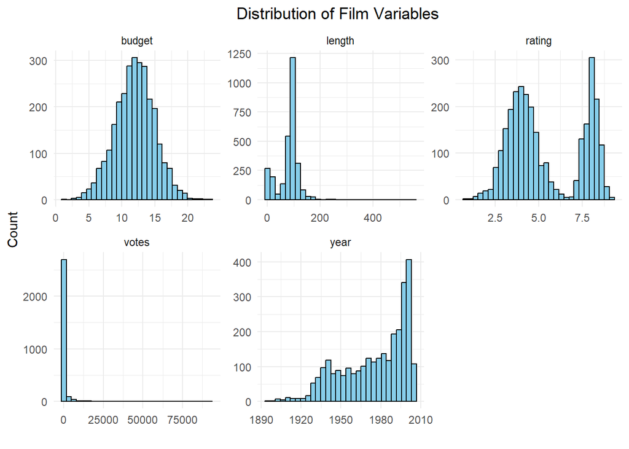

Figure 1: Distribution of Film Variables

Figure 2 shows the distribution of film genres. Drama and Action are the most common genres, each with the highest number of films, followed by Comedy. Animation and Documentary appear much less frequently, while Short films are relatively rare. Romance has the smallest number of observations. Overall, the distribution of genres is uneven, with most films concentrated in Drama, Action, and Comedy categories.

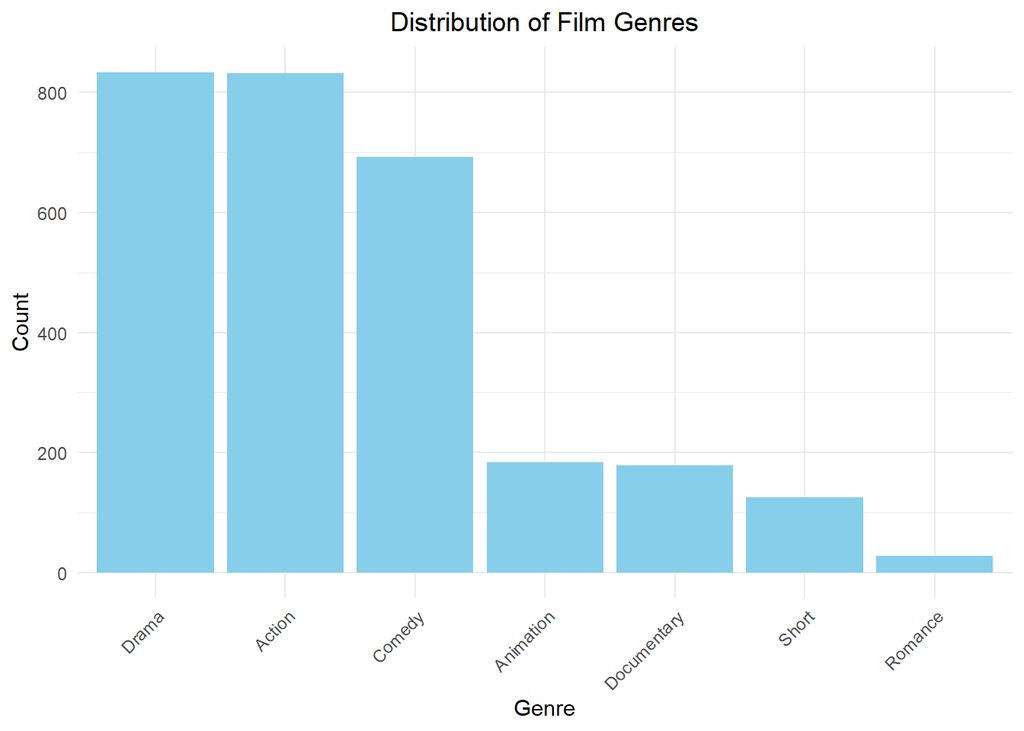

Figure 2: Distribution of Film Genres

## 2.4 Summary statistics of film varaiables by rating category

Table 4 indicates the summary statistics of film characteristics by rating category. Films with ratings greater than 7 have a slightly higher average budget (12.95) compared to films with ratings of 7 or below (11.47). However, films with lower ratings tend to have a longer average duration (95.83 minutes) than higher-rated films (55.14 minutes). In addition, films with ratings ≤ 7 receive more votes on average (827.35) than those with ratings > 7 (399.92). The mean IMDb rating differs substantially between the two groups, with an average rating of 3.99 for the lower-rated films and 8.03 for the higher-rated films. The average release year is similar for both groups, indicating no strong difference in release period between the two rating categories.

**Summary Statistics by Rating Category**

| Rating category | Count | Mean year | Mean length | Mean budget | Mean votes | Mean rating |
| --- | --- | --- | --- | --- | --- | --- |
| rating <= 7 | 1867 | 1,976.31 | 95.83 | 11.47 | 827.35 | 3.99 |
| rating > 7 | 1007 | 1,974.60 | 55.14 | 12.95 | 399.92 | 8.03 |

Figure 3 compare the distributions of several film characteristics across the two rating categories. Films with ratings greater than 7 tend to have slightly higher budgets on average compared to those with ratings of 7 or below. In contrast, lower-rated films generally have longer durations. The variable votes was log-transformed due to its highly right-skewed distribution, which helps reduce the influence of extreme values and makes the distribution easier to interpret. After the transformation, the distributions of log-transformed votes appear that films with ratings ≤ 7 receive more votes on average than those with ratings > 7. The time period of film release does not differ substantially between two rated films.

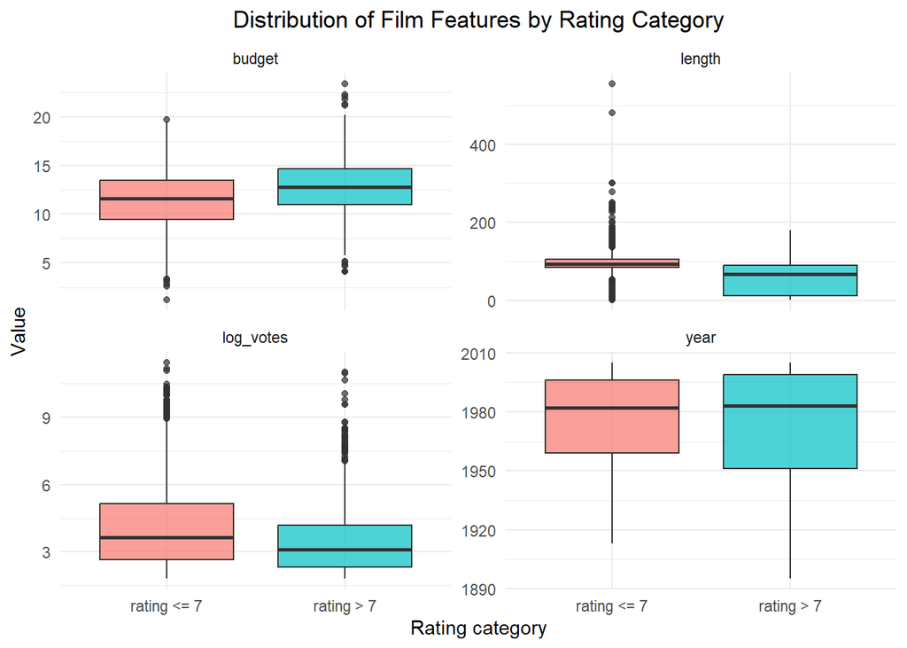

Figure 3: Distribution of Film Features by Rating Category

# 3 Formal Data Analysis

To investigate which film characteristics influence whether a film receives an IMDB rating greater than 7, we use a Generalised Linear Model (GLM) with a binomial distribution. Because the response variable has two categories (rating > 7 and rating ≤ 7), logistic regression is an appropriate modelling approach. The response variable in this model is high_rating, which equals 1 if the rating is greater than 7 and 0 otherwise. The explanatory variables included in the model are: - year (release year of the film) - length (film duration in minutes) - budget (production budget) - log_votes (log-transformed number of votes) - genre (film genre) The logistic regression model estimates how these variables affect the probability that a film receives a rating greater than 7.

| Variable | Estimate | Std Error | z value | p-value |
| --- | --- | --- | --- | --- |
| (Intercept) | −16.227 | 5.779 | −2.808 | 0.005 |
| year | 0.006 | 0.003 | 2.157 | 0.031 |
| length | −0.062 | 0.004 | −16.255 | 0.000 |
| budget | 0.519 | 0.030 | 17.430 | 0.000 |
| log_votes | 0.048 | 0.042 | 1.140 | 0.254 |
| genreAnimation | −0.428 | 0.339 | −1.265 | 0.206 |
| genreComedy | 3.338 | 0.182 | 18.328 | 0.000 |
| genreDocumentary | 5.310 | 0.388 | 13.702 | 0.000 |
| genreDrama | −1.411 | 0.231 | −6.119 | 0.000 |
| genreRomance | −0.605 | 0.893 | −0.677 | 0.499 |
| genreShort | 4.332 | 1.051 | 4.121 | 0.000 |

The variables budget and year have positive and significant effects, suggesting that films with larger budgets and more recent release years are more likely to receive ratings above 7. In contrast, length has a significant negative effect, indicating that longer films are less likely to receive high ratings. In addition, film genre plays an important role, with genres such as Comedy, Documentary, and Short films showing a higher probability of receiving ratings above 7, while Drama shows a negative relationship. The variable log_votes is not statistically significant in the model.

## 3.1 Odds ratios

Table 6: Odds Ratios from Logistic Regression

| Variable | Odds_Ratio |
| --- | --- |
| (Intercept) | 0.000 |
| year | 1.006 |
| length | 0.940 |
| budget | 1.680 |
| log_votes | 1.049 |
| genreAnimation | 0.652 |
| genreComedy | 28.170 |
| genreDocumentary | 202.395 |
| genreDrama | 0.244 |
| genreRomance | 0.546 |
| genreShort | 76.104 |

An odds ratio greater than 1 indicates an increase in the odds of receiving a high rating, while a value less than 1 indicates a decrease. The odds ratio for budget (1.68) indicates that films with larger budgets have higher odds of receiving high ratings. The odds ratio for length (0.94) is less than 1, suggesting that longer films are less likely to receive ratings above 7. In addition, some genres such as Comedy, Documentary, and Short films have much larger odds ratios, meaning films in these genres are more likely to receive high ratings compared with the reference genre.

## 3.2 Model prediction

Table 7: Confusion Matrix

| Predicted | rating <= 7 | rating > 7 |
| --- | --- | --- |
| rating <= 7 | 1733 | 170 |
| rating > 7 | 134 | 837 |

The model correctly classified 1733 films with ratings ≤ 7 and 837 films with ratings > 7. However, 170 films with high ratings were predicted as low ratings, and 134 films with low ratings were predicted as high ratings. Overall, this suggests that the model performs reasonably well in distinguishing between films with ratings above and below 7.

# 4 Conclusions

This study investigated which film characteristics influence whether a film receives an IMDB rating greater than 7. Using a Generalised Linear Model (GLM), we examined the effects of several variables including release year, film length, budget, number of votes, and genre. The results show that budget, film length, release year, and genre are important factors associated with high IMDB ratings. Films with larger budgets and more recent release years are more likely to receive ratings above 7, while longer films are less likely to receive high ratings. In addition, some genres such as Comedy, Documentary, and Short films show a higher probability of receiving high ratings compared with other genres. The prediction results from the confusion matrix also indicate that the model performs reasonably well in distinguishing between films with ratings above and below 7. Overall, the analysis suggests that both film characteristics and genre play an important role in determining whether a film receives a high IMDB rating.